Skip to poster content

ASSETS 2026 poster

Audience Choice Best Poster Award

# See What I Mean: A Technology Probe of AI Assistants for Chart Exploration with Low Vision

Yotam Sechayk<sup>1</sup>, Lucy Jiang<sup>2</sup>, Yuhang Zhao<sup>3</sup>, Takeo Igarashi<sup>1</sup>

<sup>1</sup>The University of Tokyo, <sup>2</sup>University of Washington, <sup>3</sup>University of Wisconsin–Madison

- [Paper (ACM Digital Library)](https://doi.org/10.1145/3797867.3841222)
- yotam@sechayk.com
- sechayk.com

## Problem and research questions

Problem. Magnification enlarges details but fragments the chart and loses the overview. AI chart assistants mostly serve screen reader users, yet low-vision individuals prefer using their **residual vision**.

### RQ1: How do low-vision individuals experience AI-supported chart interaction grounded in their vision?

Answer. **Sharing their view helped** under both personas: it complemented vision, reduced effort, and kept independence.

### RQ2: Should AI support systems for low-vision individuals adapt their response content?

Answer. **Adapted answers mattered**: 8 of 12 participants preferred the AI that adapts its answers to low vision, and 9 of 12 followed its directions.

Key takeaway. Adapt both sides: what the AI sees and what it says.

## During exploration: ask, follow, point

Three moments from one participant (P12) exploring a world map with the low-vision AI.

### Ask

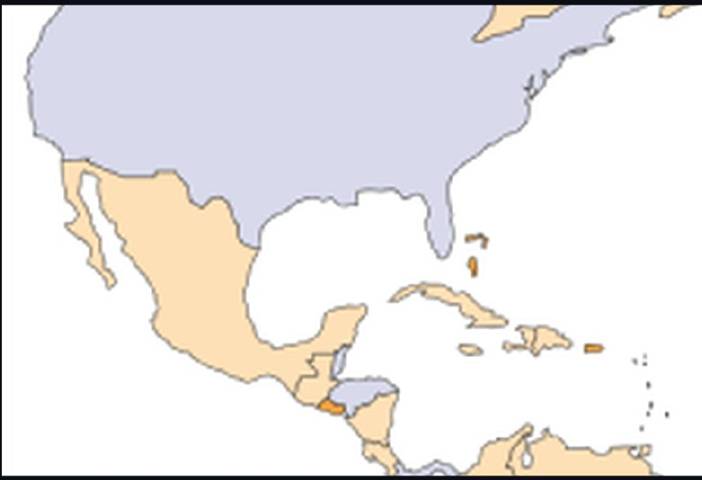

1. - Participant: Which countries have the highest female population?

   - AI: “…Outside your view to the right: Russia, Ukraine, Belarus, and Portugal.”

### Follow guidance

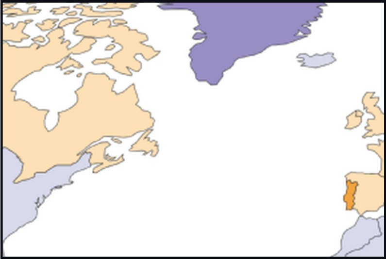

2. - Participant: Can you tell me how to find Portugal on this map?

   - AI: “Portugal is visible on the right edge of your current view, about halfway down.”

### Point to confirm

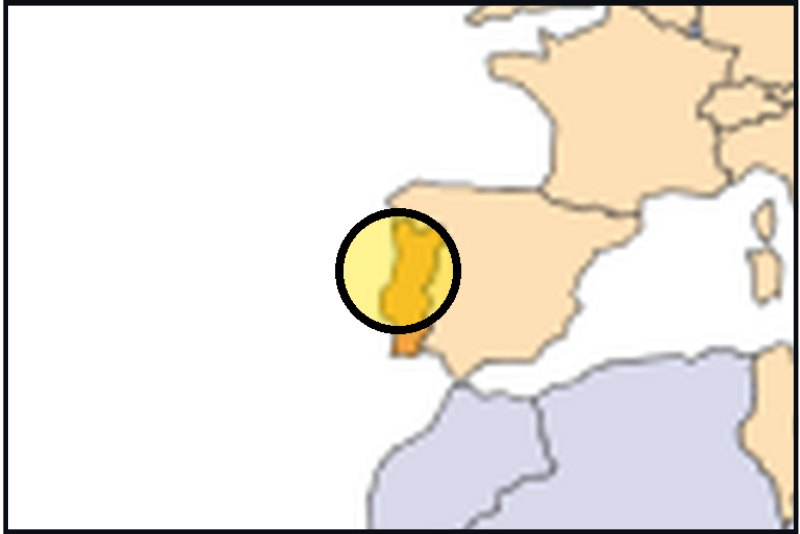

3. - Participant: [double-clicks the country]

   - AI: “You are pointing to Portugal. It is colored dark orange…”

## How the probe works: AI shares your view and interest point

Approach. The AI assistant sees what you see: your **magnified view** and **point of interest**.

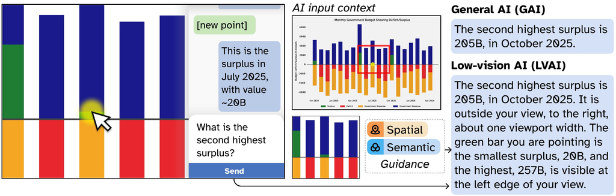

Both personas receive the same input. Their answers to “What is the second highest surplus?”:

General AI (GAI): “The second highest surplus is 205B, in October 2025.”

Low-vision AI (LVAI): “The second highest surplus is 205B, in October 2025. It is outside your view, to the right, about one viewport width. The green bar you are pointing is the smallest surplus, 20B, and the highest, 257B, is visible at the left edge of your view.”

## Technology probe study

**12 low-vision participants** explored two charts, one per AI persona: a **general AI (GAI)** and a **low-vision AI (LVAI)** that adapts its answers.

## RQ1: Sharing my view helped

- Complement visionFilled in **what vision missed**: colors, labels, and values out of view.
- Agency and independence**Asked only when needed**, without the social cost of asking a person.
- Reduce effort**One click** replaced panning, zooming, and cross-referencing.

89.6**Usability (SUS)**, out of 100.

## RQ2: Adapted answers mattered

Share of AI answers that include each type of guidance

| Guidance | Low-vision AI (LVAI) | General AI (GAI) |
| --- | --- | --- |
| Spatial guidance | 71.2% | 7.8% |
| Semantic guidance | 84.8% | 29.1% |

> “…much more specific… better suited to [their] personal needs.”

> Participant P2

> “I could click on it, it could tell me, and I could keep moving.”

> Participant P12

### Limitation

**5 of 12** found the LVAI **wordier** than they needed in the moment.

> “Sometimes I want an easy answer, value, name.”

> Participant P1

## Design recommendations

1. DR1: Anchor answers on the chartPin, highlight, and annotate in the user’s view.
2. DR2: Design for verifiabilityShow what the AI refers to, so users can check it.
3. DR3: Scale answers to the actionQuick answers for clicks, detail for typed questions.
4. DR4: Augment vision, keep agencyKeep exchanges user-initiated; the user’s view leads.